# Text mining in R

Nic Rivers

November 22, 2019

## Introduction

- Increasingly, researchers are making use of data extracted from text in quantitative studies.
- Examples:
  - Baylis (2019) on the effects of temperature on profanity and sentiment expressed on Twitter (https://www.patrickbaylis.com/pdf/Baylis_TT.pdf).
  - Yzaguirre et al. (2016) find and geo-locate historical flooding events in Nova Scotia using automated Newspaper search (https://iopscience.iop.org/article/10.1088/1755-1315/34/1/012043/pdf)

## Extracting data from text

“Madam Speaker, the opioid crisis is growing every year. The number of deaths due to overdose are increasing at an alarming rate. In 2016, there were just over 3,000 opioid related deaths in Canada. In 2017, the number jumped to almost 4,000. That is a 33% increase over just one year. These are preventable deaths. When will we see the real plan from the government to address this very troubling issue?” – Conservative MP Bob Saroya, Question Period 2018-10-26.

- What data can we extract from text?
  - Topic
  - Sentiment
  - Measures of speech complexity (word count, syllable count, readability)

## Finding words in text

```r
library(tidyverse)
library(tidytext)
saroya_long <- "Madam Speaker, the opioid crisis is growing every year. The number of deaths due to overdose are increasing at an alarming rate. In 2016, there were just over 3,000 opioid related deaths in Canada. In 2017, the number jumped to almost 4,000. That is a 33% increase over just one year. These are preventable deaths. When will we see the real plan from the government to address this very troubling issue?"
```

```r
# A shorter string
saroya <- "Madam Speaker, the opioid crisis is growing every year."

# Does the text contain the word "opioid"?
str_detect(saroya, "opioid")
```

```
## [1] TRUE
```

```r
# Does the text contain the word "climate change"?
str_detect(saroya, "climate change")
```

```
## [1] FALSE
```

## Dealing with cases

```r
# Dealing with cases
str_detect(saroya, "OPIOID")
```

```
## [1] FALSE
```

```r
str_detect(saroya, regex("OPIOID", ignore_case = TRUE))
```

```
## [1] TRUE
```

```r
# Wildcards
str_detect(saroya, ".eak.")
```

```
## [1] TRUE
```

## Tidy text

The tidytext library allows for processing text by converting text into tidy data: one token – word, sentence, etc. – per line. The unnest_tokens() function separates text into tokens.

```r
tibble(text = saroya) %>%
  unnest_tokens(word, text)
```

```
## # A tibble: 9 x 1
##   word
##   <chr>
## 1 madam
## 2 speaker
## 3 the
## 4 opioid
## 5 crisis
## 6 is
## 7 growing
## 8 every
## 9 year
```

## Counting word occurrences

Once we have the text tokenized, we can use our usual data handling tools. For example, we can count occurrences of words.

```r
tibble(text = saroya_long) %>%
   unnest_tokens(word, text) %>%
   group_by(word) %>%
   summarise(n=n()) %>% arrange(desc(n)) %>% top_n(3)
```

```
## # A tibble: 4 x 2
##   word       n
##   <chr>  <int>
## 1 the        5
## 2 deaths     3
## 3 in         3
## 4 to         3
```

## Getting rid of common (stop) words

We aren’t usually interested in words like “the”, “and”, “is”, etc. These are stored in a data frame called `stop_words`. (You can examine `stop_words`).

We can get rid of them using anti_join.

```r
tibble(text = saroya_long) %>%
   unnest_tokens(word, text) %>%
  anti_join(stop_words) %>%
   group_by(word) %>%
   summarise(n=n()) %>% arrange(desc(n)) %>% top_n(2)
```

```
## # A tibble: 2 x 2
##   word       n
##   <chr>  <int>
## 1 deaths     3
## 2 opioid     2
```

## Topic analysis in multiple texts

It is straightforward to apply these techniques to many texts at the same time – that’s where they get powerful. For example, rather than looking at just one MP speech, lets look at them all (for 2018). The data frame `speeches` contains all the speeches made in the House of Commons (in 2018).

```r
speeches <- read_csv("hoc2018speeches.csv")
head(speeches,3)
```

```
## # A tibble: 3 x 7
##   speechdate maintopic subtopic speechtext speakerparty speakerriding
##   <date>     <chr>     <chr>    <chr>      <chr>        <chr>
## 1 2018-01-29 Private ~ Automat~ The House~ <NA>         <NA>
## 2 2018-01-29 Private ~ Automat~ "Mr. Spea~ Liberal      TorontoDanf~
## 3 2018-01-29 Private ~ Automat~ "Mr. Spea~ New Democra~ BeloeilCham~
## # ... with 1 more variable: speakername <chr>
```

## All speeches on a given topic

All speeches containg the word “opioid”.

```r
speeches %>%
  mutate(contains_word = str_detect(speechtext, regex("opioid", ignore_case = TRUE))) %>%
  filter(contains_word == TRUE) %>%
  head(3)
```

```
## # A tibble: 3 x 8
##   speechdate maintopic subtopic speechtext speakerparty speakerriding
##   <date>     <chr>     <chr>    <chr>      <chr>        <chr>
## 1 2018-10-01 Adjournm~ Justice  "Madam Sp~ Conservative "BeauportCô~
## 2 2018-10-01 Adjournm~ Justice  "Madam Sp~ <NA>         <NA>
## 3 2018-10-01 Adjournm~ Justice  "Madam Sp~ Conservative "BeauportCô~
## # ... with 2 more variables: speakername <chr>, contains_word <lgl>
```

## Frequency of speeches on a given topic

Let’s find all the speeches containg the word “carbon tax”. Then let’s find the proportion of all the speeches by each party that contain the word “carbon tax”. The conservatives spent a lot of time talking about the carbon tax in 2018.

```r
speeches %>%
  mutate(contains_word = str_detect(speechtext, regex("carbon tax", ignore_case = TRUE))) %>%
  group_by(speakerparty) %>%
  filter(speakerparty %in% c("Conservative", "New Democratic Party", "Liberal"),
         !is.na(contains_word)) %>%
  summarise(freq = sum(contains_word) / n()) %>%
  mutate(freq = scales::percent(freq))
```

```
## # A tibble: 3 x 2
##   speakerparty         freq
##   <chr>                <chr>
## 1 Conservative         8.71%
## 2 Liberal              0.33%
## 3 New Democratic Party 1.06%
```

## tidytext integrates with ggplot

Speeches on carbon tax over time

```r
library(lubridate) # for dealing with dates
date_ct <- speeches %>%
  mutate(contains_word = str_detect(speechtext, regex("carbon tax", ignore_case = TRUE)),
         month_label = month(speechdate, label=TRUE),
         month = month(speechdate)) %>%
  group_by(speakerparty, month, month_label) %>%
  filter(speakerparty %in% c("Conservative", "New Democratic Party", "Liberal"),
         !is.na(contains_word)) %>%
  summarise(freq = sum(contains_word) / n())
```

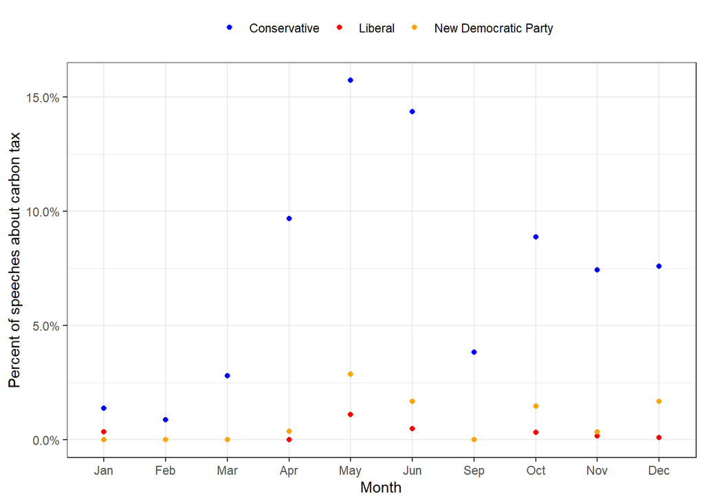

```r
ggplot(date_ct, aes(x=month_label, y=freq, colour=speakerparty)) + geom_point() +
           theme_bw() +
  theme(legend.position="top") +
           labs(x="Month",
                y="Percent of speeches about carbon tax") +
  scale_y_continuous(labels=scales::percent_format()) +
  scale_color_manual(name=NULL, values=c("Conservative" = "blue",
                                           "Liberal" = "red",
                                           "New Democratic Party" = "orange"))
```

## Tokenizing a corpus

We can tokenize the entire corpus of 2018 speeches, so that one word appears on each line of the data frame.

```r
speeches_tokenized <- speeches %>%
  unnest_tokens(word, speechtext) %>%
  filter(!is.na(speakername),
         speakerparty %in% c("Conservative", "New Democratic Party", "Liberal"),
         !is.na(maintopic)) %>%
  anti_join(stop_words) %>%
  select(speechdate, speakerparty, speakername, speakerriding, word)
head(speeches_tokenized)
```

```
## # A tibble: 6 x 5
##   speechdate speakerparty speakername    speakerriding    word
##   <date>     <chr>        <chr>          <chr>            <chr>
## 1 2018-01-29 Liberal      Julie Dabrusin TorontoDanforth speaker
## 2 2018-01-29 Liberal      Julie Dabrusin TorontoDanforth happy
## 3 2018-01-29 Liberal      Julie Dabrusin TorontoDanforth happy
## 4 2018-01-29 Liberal      Julie Dabrusin TorontoDanforth participate
## 5 2018-01-29 Liberal      Julie Dabrusin TorontoDanforth debate
## 6 2018-01-29 Liberal      Julie Dabrusin TorontoDanforth motion
```

## Counting word frequencies

Just like in the simple text, we can use our `dplyr` methods to analyze the tokenized corpus. First, let’s look at the main words used by each party.

```r
speeches_tokenized %>%
  group_by(speakerparty, word) %>%
  summarise(n=n()) %>%
  arrange(desc(n)) %>%
  top_n(3) %>%
  ungroup()
```

```
## # A tibble: 9 x 3
##   speakerparty         word           n
##   <chr>                <chr>      <int>
## 1 Conservative         government 15459
## 2 Conservative         minister   10943
## 3 Liberal              speaker    10799
## 4 Liberal              government 10510
## 5 Conservative         bill        9868
## 6 Liberal              canada      9587
## 7 New Democratic Party government  8645
## 8 New Democratic Party bill        5015
## 9 New Democratic Party speaker     4725
```

## Counting word frequencies

Let’s compare word use by party.

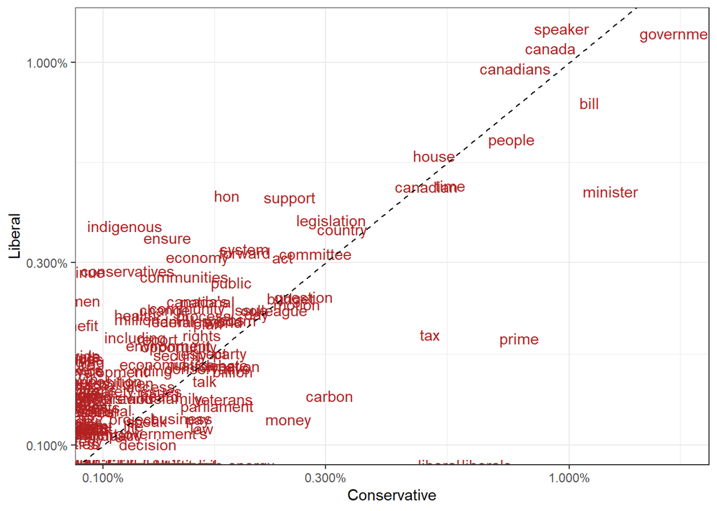

```r
words_by_party <- speeches_tokenized %>%
  group_by(speakerparty, word) %>%
  summarise(n=n()) %>%
  mutate(num = str_detect(word,"[0-9]+")) %>%
  filter(num == FALSE) %>%
  group_by(speakerparty) %>%
  mutate(word_freq=n/sum(n)) %>%
  select(speakerparty, word, word_freq) %>%
  filter(word_freq > 0.001) %>%
  spread(key=speakerparty, value=word_freq, fill=0)

  ggplot(words_by_party, aes(x=Conservative, y=Liberal)) +
  geom_text(aes(label=word), colour="firebrick") +
  geom_abline(slope=1, intercept=0, linetype="dashed") +
  theme_bw() +
  scale_x_log10(labels=scales::percent_format()) +
  scale_y_log10(labels=scales::percent_format())
```

## What about incidence of a particular word by speaker?

Which MP talked most about the opioid crisis?

```r
opioid_mps <- speeches %>%
  group_by(speakerparty, speakername) %>%
  mutate(opioid = str_detect(speechtext, "opioid")) %>%
  summarise(speech_fraction=sum(opioid)/n()) %>%
  filter(speakerparty %in% c("Conservative", "New Democratic Party", "Liberal")) %>%
  arrange(desc(speech_fraction)) %>%
  top_n(10)
```

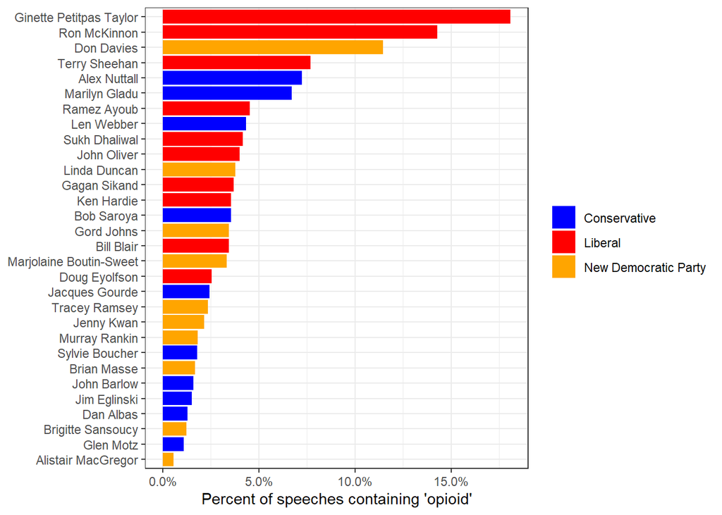

```r
  ggplot(opioid_mps, aes(x=reorder(speakername,speech_fraction), y=speech_fraction, fill=speakerparty)) +
  geom_col() +
  scale_fill_manual(name=NULL, values=c("Conservative" = "blue",
                                           "Liberal" = "red",
                                           "New Democratic Party" = "orange")) +
  coord_flip() +
  labs(y="Percent of speeches containing 'opioid'",
       x=NULL) +
  theme_bw() +
    scale_y_continuous(labels=scales::percent_format())
```

## Seniment analysis

The `tidytext` package comes with three sets of words that are coded to reflect sentiments. In the `afinn` sentiment-coded words, the sentiment scale runs from -5 to +5, with more positive numbers reflecting more positive sentiments. Let’s take a look:

```r
get_sentiments("afinn") %>% group_by(value) %>% summarise(word=first(word))
```

```
## # A tibble: 11 x 2
##    value word
##    <dbl> <chr>
##  1    -5 bastard
##  2    -4 ass
##  3    -3 abhor
##  4    -2 abandon
##  5    -1 absentee
##  6     0 some kind
##  7     1 aboard
##  8     2 abilities
##  9     3 admire
## 10     4 amazing
## 11     5 breathtaking
```

We can use these sentiment-rated words to analyze speech.

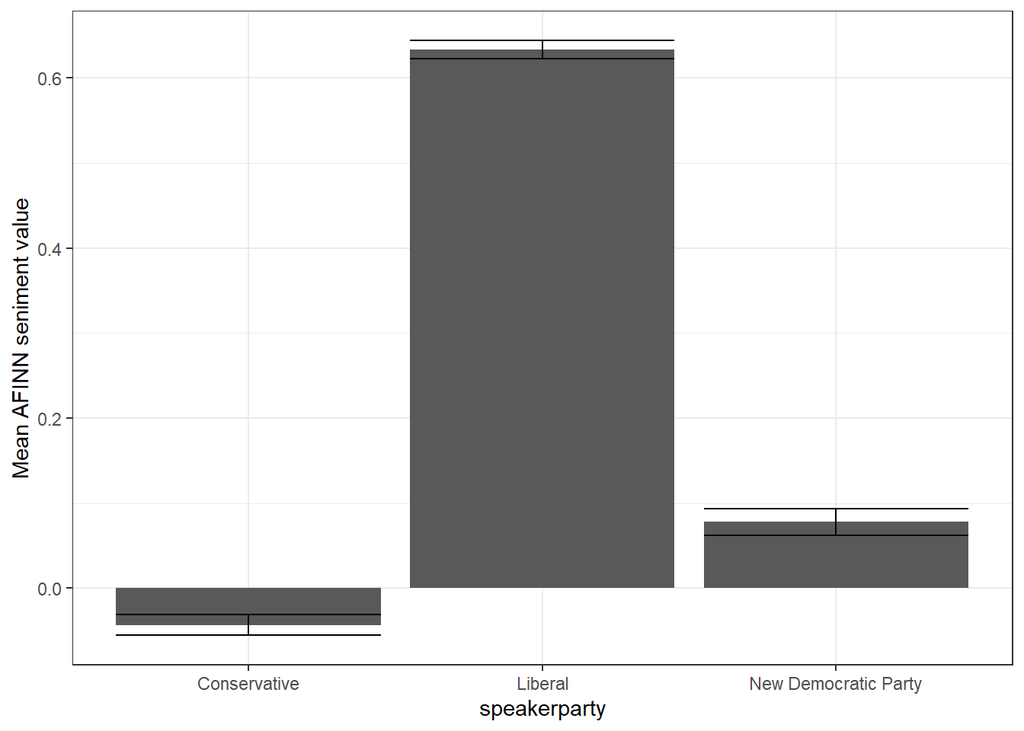

```r
sentiments1 <- get_sentiments("afinn")
speech_sentiments <- speeches_tokenized %>%
  anti_join(stop_words) %>% # This gets rid of joining words
  inner_join(sentiments1) %>%
  group_by(speakerparty) %>%
  summarise(meanscore = mean(value),
            sdev = sd(value),
            n = n(),
            se=sdev/sqrt(n)) %>%
  filter(n>100)

  ggplot(speech_sentiments) +
  geom_col(aes(x=speakerparty, y=meanscore)) +
  geom_errorbar(aes(x=speakerparty, ymin=meanscore-1.96*se, ymax=meanscore+1.96*se)) +
  theme_bw() +
  labs(y="Mean AFINN seniment value")
```

## We can look at the most positive and negative members of parliament

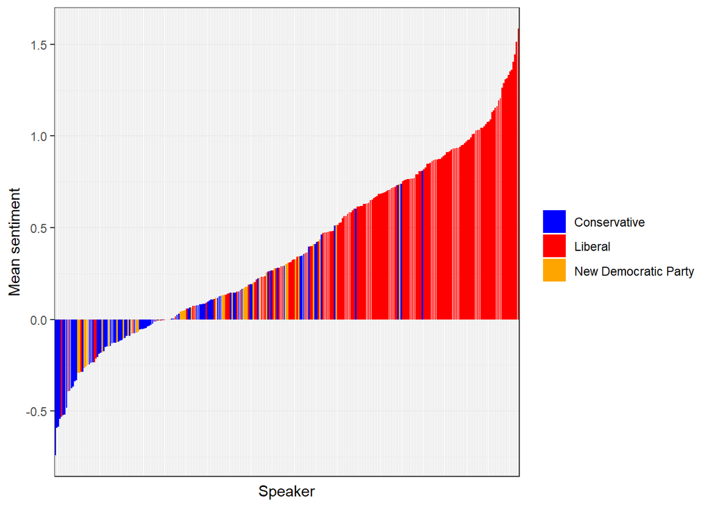

```r
mp_sentiments <- speeches_tokenized %>%
  anti_join(stop_words) %>% # This gets rid of joining words
  inner_join(sentiments1) %>%
  group_by(speakerparty,speakername) %>%
  summarise(meanscore = mean(value),
            n = n()) %>%
  filter(n>150)

  ggplot(mp_sentiments) +
  geom_col(aes(x=reorder(speakername, meanscore), y=meanscore, fill=speakerparty)) +
  theme_bw() +
  labs(y="Mean AFINN seniment value") +
  scale_fill_manual(name=NULL, values=c("Conservative" = "blue",
                                           "Liberal" = "red",
                                           "New Democratic Party" = "orange")) +
    theme_bw() +
  theme(axis.text.x = element_blank(),
        axis.ticks.x = element_blank()) +
  labs(x="Speaker", y="Mean sentiment")
```

## Let’s put these on a map

Just for fun!

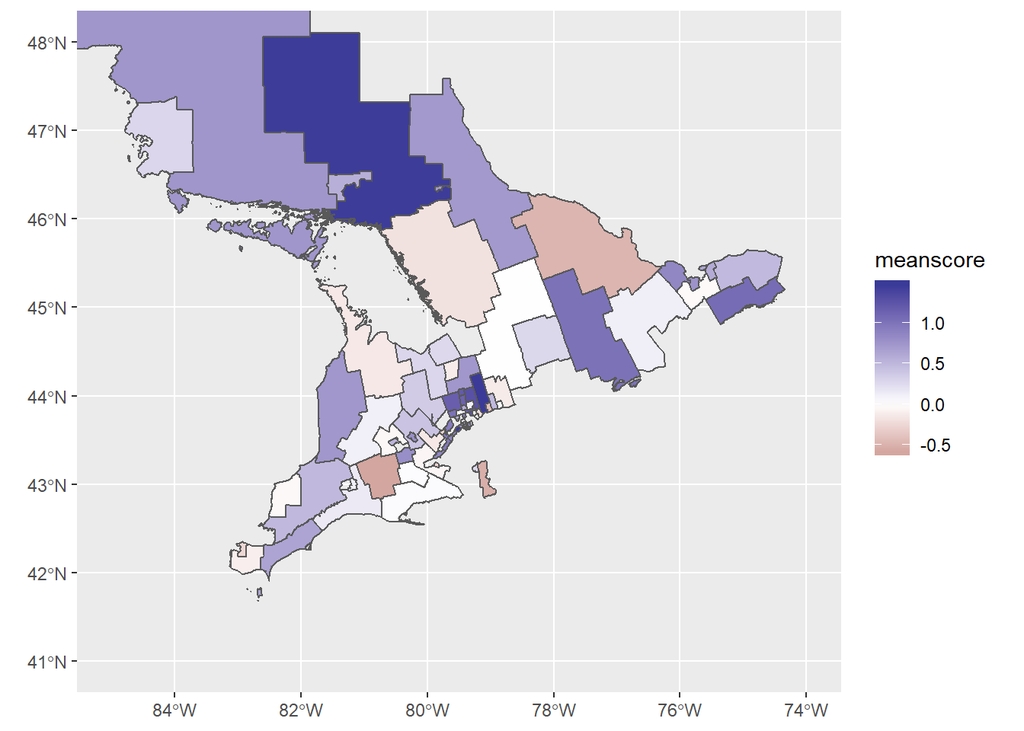

```r
library(sf)
# Boundary files from from here: https://www12.statcan.gc.ca/census-recensement/2011/geo/bound-limit/bound-limit-eng.cfm
shp <- read_sf("lfed000b16a_e/lfed000b16a_e.shp")
sents <- speeches_tokenized %>%
  anti_join(stop_words) %>% # This gets rid of joining words
  inner_join(sentiments1) %>%
  group_by(speakerparty,speakerriding) %>%
  summarise(meanscore = mean(value),
            n = n()) %>%
  rename(FEDNAME = speakerriding) %>%
  mutate(FEDNAME = str_replace_all(FEDNAME,"[:^alpha:]",""))
shp_sents <- inner_join(shp %>%
                          mutate(FEDNAME = str_replace_all(FEDNAME,"[:^alpha:]","")), sents)
ggplot(shp_sents %>% filter(PRUID==35)) + geom_sf(aes(fill=meanscore)) +
  scale_fill_gradient2() +
  coord_sf(xlim=c(-85,-74),ylim=c(41,48),crs=4326)
```

## What about a word cloud?

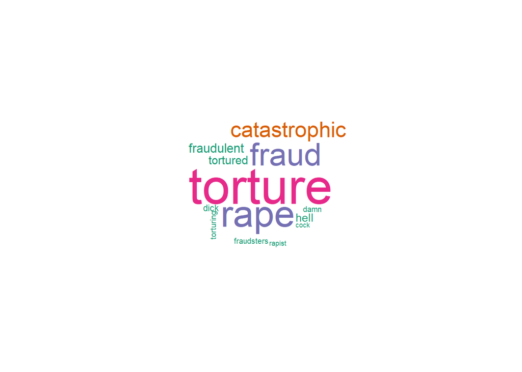

```r
library(wordcloud)
# Let's plot nasty words used in parliament
nasty_words <- speeches_tokenized %>%
  anti_join(stop_words) %>% # This gets rid of joining words
  inner_join(sentiments1) %>%
  filter(value <= -4) %>%
  group_by(word) %>%
  summarise(count=n())
# Make some nice colours
pal <- brewer.pal(4, "Dark2")

nasty_words %>%
  with(wordcloud(word, count, random.order = FALSE, colors=pal))
```

Now let’s repeat with the happy words:

```r
happy_words <- speeches_tokenized %>%
  anti_join(stop_words) %>% # This gets rid of joining words
  inner_join(sentiments1) %>%
  filter(value >= 4) %>%
  group_by(word) %>%
  summarise(count=n())
```

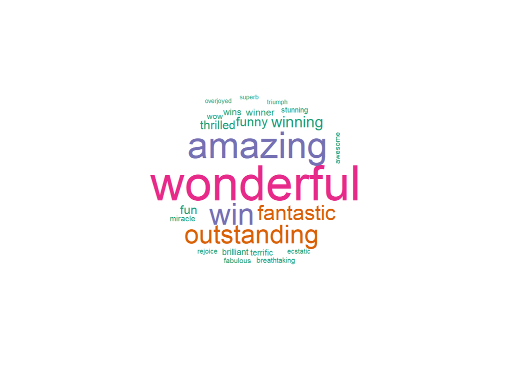

```r
# Make some nice colours
pal <- brewer.pal(4, "Dark2")

happy_words %>%
  with(wordcloud(word, count, random.order = FALSE, colors=pal))
```